# 单变量绘图选择

# 多变量分析

### 探讨你在这部分探究中观察到的一些关系。通过观察感兴趣的特性，是否存在相互促进的特性？

在线性负相关的前提下，quality越高，citric.acid越高，ph越低；在线正性相关的前提下，quality越高，citric.acid越高，fixed.acidity越高；在线性正相关的前提下，quality越高，fixed.acidity越低，density越低

### 这些特性之间是否存在有趣或惊人的联系呢？

由于相互之间的线性关系，存在连续线性关系，即citric.acid越高，fixed.acidity越高，density越高，pH越低

### 选项：你是否创建过数据集的任何模型？讨论你模型的优缺点。

lm模型，可能由于数据分布的不均衡，(quality为5,6的数据偏多)，拟合效果不是很好

# 定稿图与总结

### 绘图一

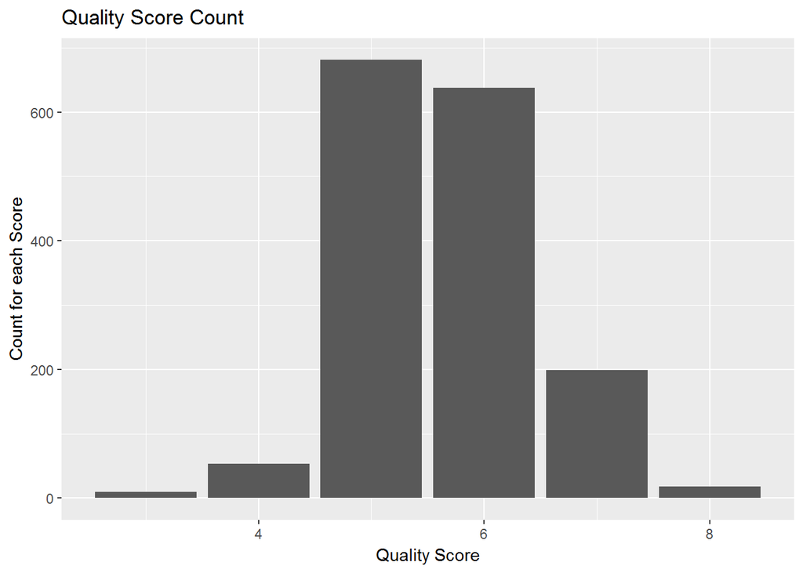

### 描述一

可以看出quality为5和6的项是最多的，可能是由于数据不均衡造成的

### 绘图二

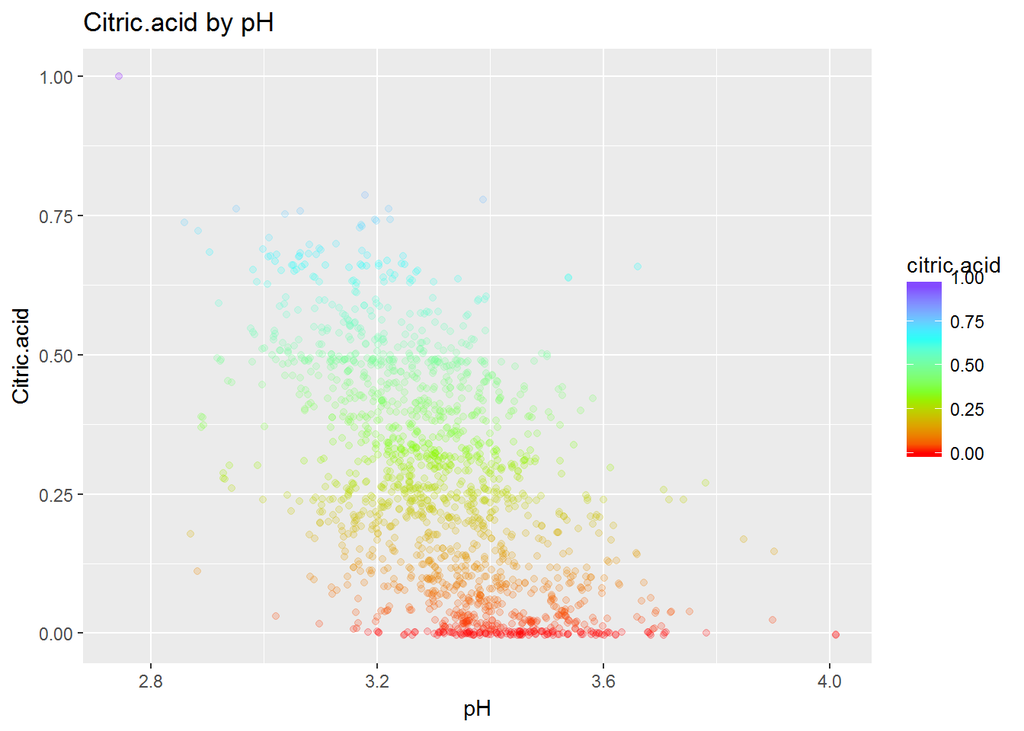

### 描述二

负相关关系，pH的测量与酸性有关，citric.acid也是算的一种

### 绘图三

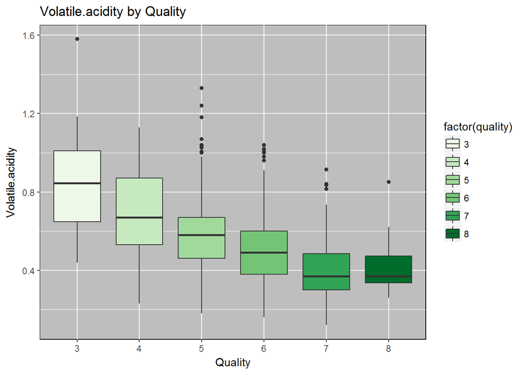

### 描述三

可以看出Volatile.acidity基本随着quliaty的上升而下降，符合变量说明中的“the amount of acetic acid in wine, which at too high of levels can lead to an unpleasant, vinegar taste”

# 反思

这个数据集本身包含了1500多种葡萄酒的各种成分和quality评分。从对各个变量的单变量分析，我对葡萄酒的质量分数比较感兴趣，于是从说明文档入手，分析了与质量相关的成分与质量之间的关系，但可能由于质量分数是分类变量，与成分这种连续变量之间的关系并不强，于是我又分析了成分与成分之间的关系，其中，pH值与多种成分的相关系数相对较高，如fixed.acidity，citric.acid；还有volatile.acidity与citric.acid之间，fixed.acidity与density之间，fixed.acidity与citric.acid之间都有较强相关关系。 对quality与其他因素的线性模拟不是很理想，一个是因为quality不是连续变量，在分析中比较不好量化，还有就是quality的分布不均衡，5,6的质量分数相对其他分数明显过多。最后，这个数据集是2009年收集的，到今天已经接近10年了，即使模拟出来的数据也可能不是很匹配了。 这个项目目前学到的模型有限，分析出来的结果也有限，希望未来通过课程的学习和自学能够掌握其他数据模型的分析方法或者线性函数的高阶运用，来分析这个数据集，更好地拟合对红酒质量影响的函数